# Plackett-Luce Trees

Kauê de Sousa

2021

# Set up

For this lecture we need to packages following packages. We load the packages with `library()`.

```r
library("PlackettLuce")
library("qvcalc")
library("gosset")
library("patchwork")
library("ggparty")
library("climatrends")
library("nasapower")
library("ClimMobTools")
```

# Example 1: Sweetpotato data

We first read the .csv file with the function `read.csv()`

```r
dt <- read.csv("data/sweet_potato.csv")
```

```r
str(dt)
```

```
## 'data.frame':    1433 obs. of  20 variables:
##  $ id            : int  6 18 24 25 27 56 62 63 73 74 ...
##  $ country       : chr  "Uganda" "Uganda" "Uganda" "Uganda" ...
##  $ district      : chr  "Gulu" "Gulu" "Gulu" "Gulu" ...
##  $ gender        : chr  "Woman" "Woman" "Man" "Man" ...
##  $ trial         : chr  "community" "community" "community" "community" ...
##  $ item_A        : chr  "NASPOT 10 (Kabode)" "Kakamega" "NASPOT 13" "NASPOT 12" ...
##  $ item_B        : chr  "NASPOT 12" "NASPOT 8" "NASPOT 10 (Kabode)" "NASPOT 10 (Kabode)" ...
##  $ item_C        : chr  "NASPOT 13" "NASPOT 13" "Kakamega" "NASPOT 13" ...
##  $ best_overall  : chr  "B" "B" "A" "A" ...
##  $ worst_overall : chr  "A" "A" "C" "B" ...
##  $ best_taste    : chr  "C" "B" "A" "A" ...
##  $ worst_taste   : chr  "B" "C" "C" "B" ...
##  $ best_color    : chr  "B" "C" "B" "C" ...
##  $ worst_color   : chr  "C" "B" "A" "A" ...
##  $ best_describe : chr  "It has high dry matter content" "nice, sweet" "sweet" "very sweet and nice" ...
##  $ worst_describe: chr  "not too sweet" "sweet" "wet" "it is wet and not sweet" ...
##  $ community     : chr  NA NA NA NA ...
##  $ age           : chr  NA NA NA NA ...
##  $ geno_test     : chr  NA NA NA NA ...
##  $ region        : chr  NA NA NA NA ...
```

For this analysis we keep only the Ghana data

```r
dt <- dt[dt$country == "Ghana", ]
```

And then we transform the tricot rankings into a PlackettLuce rankings. We use the overall preference on the genotypes

```r
R <- rank_tricot(data = dt,
                 items = c("item_A","item_B","item_C"),
                 input = c("best_overall","worst_overall"))


head(R)
```

```
##                                        419
## "SARI-Nan > SARI-Diedi (Tu-Purple) >  ..."
##                                        420
## "PG17305-N1 > SARI-Diedi (Tu-Purple)  ..."
##                                        421
## "SARI-Diedi (Tu-Purple) > PG17305-N1  ..."
##                                        422
## "SARI-Nyumingre (Obare) > PG17305-N1  ..."
##                                        423
## "SARI-Nyumingre (Obare) > PG17265-N1  ..."
##                                        424
## "SARI-Nyumingre (Obare) > PG17140-N2  ..."
```

## Fit a PlackettLuce model

To fit a PlackettLuce model we use the function `PlackettLuce()`. To know more about the model read the paper by [Turner et al (2020)](https://doi.org/10.1007/s00180-020-00959-3).

```r
mod <- PlackettLuce(R)

summary(mod)
```

```
## Call: PlackettLuce(rankings = R)
##
## Coefficients:
##                        Estimate Std. Error z value Pr(>|z|)
## CIP442162               0.00000         NA      NA       NA
## CRI-Apomuden           -0.50383    0.18382  -2.741 0.006128 **
## CRI-Ligri              -0.29860    0.18349  -1.627 0.103664
## PG17136-N1              0.60760    0.20933   2.903 0.003700 **
## PG17140-N2             -0.97825    0.21498  -4.550 5.35e-06 ***
## PG17206-N5             -0.42867    0.20743  -2.067 0.038774 *
## PG17265-N1             -0.30215    0.20639  -1.464 0.143194
## PG17305-N1             -0.03831    0.20502  -0.187 0.851767
## PG17362-N1             -0.19461    0.20701  -0.940 0.347154
## PG17412-N2             -0.64490    0.20807  -3.099 0.001939 **
## PGN14011-24            -0.46418    0.22658  -2.049 0.040494 *
## PGN16021-39            -0.38181    0.22402  -1.704 0.088322 .
## PGN16024-27            -0.53794    0.22304  -2.412 0.015870 *
## PGN16024-28            -0.39930    0.22308  -1.790 0.073469 .
## PGN16030-30            -0.88195    0.23026  -3.830 0.000128 ***
## PGN16092-6             -0.43790    0.22537  -1.943 0.052011 .
## PGN16130-4             -0.45238    0.22236  -2.034 0.041904 *
## PGN16203-18            -0.52260    0.22491  -2.324 0.020149 *
## SARI-Diedi (Tu-Purple) -0.53984    0.18336  -2.944 0.003239 **
## SARI-Nan                0.14675    0.18539   0.792 0.428611
## SARI-Nyumingre (Obare)  0.16792    0.18411   0.912 0.361734
## ---
## Signif. codes:  0 '***' 0.001 '**' 0.01 '*' 0.05 '.' 0.1 ' ' 1
##
## Residual deviance:  3501.8 on 3025 degrees of freedom
## AIC:  3541.8
## Number of iterations: 16
```

We define a reference item (variety). This helps us in identifying whether a widely used variety is better of worse than the new genotypes.

```r
ref = "SARI-Nyumingre (Obare)"

summary(mod, ref = ref)
```

```
## Call: PlackettLuce(rankings = R)
##
## Coefficients:
##                        Estimate Std. Error z value Pr(>|z|)
## CIP442162              -0.16792    0.18411  -0.912 0.361734
## CRI-Apomuden           -0.67175    0.14676  -4.577 4.71e-06 ***
## CRI-Ligri              -0.46652    0.14647  -3.185 0.001447 **
## PG17136-N1              0.43968    0.18730   2.347 0.018905 *
## PG17140-N2             -1.14617    0.19745  -5.805 6.44e-09 ***
## PG17206-N5             -0.59659    0.18389  -3.244 0.001178 **
## PG17265-N1             -0.47007    0.18375  -2.558 0.010521 *
## PG17305-N1             -0.20623    0.18108  -1.139 0.254754
## PG17362-N1             -0.36253    0.18769  -1.932 0.053420 .
## PG17412-N2             -0.81282    0.18591  -4.372 1.23e-05 ***
## PGN14011-24            -0.63210    0.18666  -3.386 0.000708 ***
## PGN16021-39            -0.54973    0.18557  -2.962 0.003054 **
## PGN16024-27            -0.70586    0.18201  -3.878 0.000105 ***
## PGN16024-28            -0.56722    0.18167  -3.122 0.001794 **
## PGN16030-30            -1.04987    0.19282  -5.445 5.19e-08 ***
## PGN16092-6             -0.60582    0.18555  -3.265 0.001094 **
## PGN16130-4             -0.62030    0.18331  -3.384 0.000715 ***
## PGN16203-18            -0.69052    0.18389  -3.755 0.000173 ***
## SARI-Diedi (Tu-Purple) -0.70776    0.14694  -4.817 1.46e-06 ***
## SARI-Nan               -0.02117    0.14910  -0.142 0.887103
## SARI-Nyumingre (Obare)  0.00000         NA      NA       NA
## ---
## Signif. codes:  0 '***' 0.001 '**' 0.01 '*' 0.05 '.' 0.1 ' ' 1
##
## Residual deviance:  3501.8 on 3025 degrees of freedom
## AIC:  3541.8
## Number of iterations: 16
```

The model coefficients can be obtained using the function `coef()`. The first example take the coefficients in the log format, the log-worth. If we apply the argument `log = FALSE` this returns the probability of winning (worth). The sum of these probabilities should always be 1.

```r
coef(mod, ref = ref)
```

```
##              CIP442162           CRI-Apomuden              CRI-Ligri
##            -0.16791946            -0.67174879            -0.46652334
##             PG17136-N1             PG17140-N2             PG17206-N5
##             0.43967813            -1.14617258            -0.59659002
##             PG17265-N1             PG17305-N1             PG17362-N1
##            -0.47007388            -0.20623080            -0.36253350
##             PG17412-N2            PGN14011-24            PGN16021-39
##            -0.81282308            -0.63209741            -0.54972776
##            PGN16024-27            PGN16024-28            PGN16030-30
##            -0.70586233            -0.56721708            -1.04987293
##             PGN16092-6             PGN16130-4            PGN16203-18
##            -0.60581769            -0.62029882            -0.69052107
## SARI-Diedi (Tu-Purple)               SARI-Nan SARI-Nyumingre (Obare)
##            -0.70775981            -0.02116773             0.00000000
```

```r
coef(mod, log = FALSE)
```

```
##              CIP442162           CRI-Apomuden              CRI-Ligri
##             0.06235524             0.03767581             0.04625843
##             PG17136-N1             PG17140-N2             PG17206-N5
##             0.11448517             0.02344353             0.04061661
##             PG17265-N1             PG17305-N1             PG17362-N1
##             0.04609448             0.06001151             0.05132786
##             PG17412-N2            PGN14011-24            PGN16021-39
##             0.03271861             0.03919973             0.04256530
##            PGN16024-27            PGN16024-28            PGN16030-30
##             0.03641223             0.04182734             0.02581341
##             PGN16092-6             PGN16130-4            PGN16203-18
##             0.04024354             0.03966497             0.03697515
## SARI-Diedi (Tu-Purple)               SARI-Nan SARI-Nyumingre (Obare)
##             0.03634321             0.07221151             0.07375635
```

```r
sum(coef(mod, log = FALSE))
```

```
## [1] 1
```

We can plot these coefficients with the error bars using the function `qvcalc()`

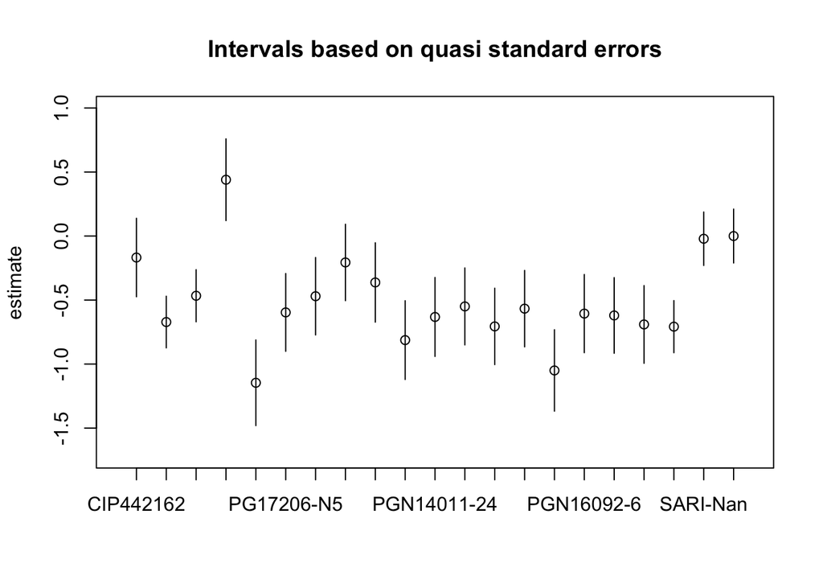

```r
plot(qvcalc(mod, ref = ref))
```

## PlackettLuce with covariates

With the function `pltree()` we can fit a PlackettLuce model recursively to find instabilities in the rankings that are represented by a set of covariates. The rankings are recursively split into two groups according to their value on covariates whose values vary between rankings, and a PlackettLuce model is fitted to each subgroup formed. The method proceeds as follows:

1. Fit a Plackett–Luce model to the full data.
2. Assess the stability of the worth parameters with respect to each covariate. That is, test for a structural change in the ranking-level contributions to the first derivatives of the log-likelihood, when these contributions are ordered by covariate values.
3. If there is significant instability, split the full data by the covariate with the strongest instability, using the cut-point that gives the highest improvement in model fit.
4. Repeat steps 1-3 for each subgroup until there are no more significant instabilities, or a split produces a subgroup below a given size threshold.

We select the covariates age and gender. We coerce age into integer and gender into factor.

```r
sel <- c("age", "gender")

covar <- dt[sel]

covar$age <- as.integer(covar$age)
covar$gender <- as.factor(covar$gender)
```

Let’s check for NA’s in these variables. We use the function `apply()` to run over the rows of covar an look for the sum of NAs in each row. A value of 0 means no NA, which is what we are looking for.

```r
sum(is.na(covar))
```

```
## [1] 8
```

```r
keep <- apply(covar, 1, function(x){
  sum(is.na(x))
})

keep <- keep == 0
```

Apply the filter in the dt and covar data frames

```r
covar <- covar[keep, ]
dt <- dt[keep, ]
```

We then use the function `rank_tricot()` to create the `grouped_rankings`. This allows the rankings to be linked to the covariates and fit the model using `pltree()`. The rankings are combined with the covariates using the function `cbind()`.

```r
G <- rank_tricot(data = dt,
                 items = c("item_A","item_B","item_C"),
                 input = c("best_overall","worst_overall"),
                 group = TRUE)

pldt <- cbind(G, covar)

head(pldt)
```

```
##                        G age gender
## 419 SARI-Nan > SARI- ...  26    Man
## 420 PG17305-N1 > SAR ...  37    Man
## 421 SARI-Diedi (Tu-P ...  35    Man
## 422 SARI-Nyumingre ( ...  25    Man
## 423 SARI-Nyumingre ( ...  36    Man
## 424 SARI-Nyumingre ( ...  42    Man
```

Now we can fit the tree. The first argument is the formula with response variable being the first followed by the covariates indicated with a `~` sign.

```r
pl <- pltree(G ~ age + gender, data = pldt, alpha = 0.1)

summary(pl)
```

```
## $`2`
## Call: PlackettLuce(rankings = y, weights = weights, na.action = NULL,
##     start = start)
##
## Coefficients:
##                         Estimate Std. Error z value Pr(>|z|)
## CIP442162               0.000000         NA      NA       NA
## CRI-Apomuden           -0.561385   0.205699  -2.729 0.006350 **
## CRI-Ligri              -0.272198   0.205269  -1.326 0.184821
## PG17136-N1              0.439174   0.232960   1.885 0.059404 .
## PG17140-N2             -1.139375   0.245704  -4.637 3.53e-06 ***
## PG17206-N5             -0.653822   0.238588  -2.740 0.006137 **
## PG17265-N1             -0.386940   0.234359  -1.651 0.098727 .
## PG17305-N1             -0.003812   0.232765  -0.016 0.986935
## PG17362-N1             -0.378680   0.235082  -1.611 0.107214
## PG17412-N2             -0.657257   0.237991  -2.762 0.005750 **
## PGN14011-24            -0.403071   0.253849  -1.588 0.112323
## PGN16021-39            -0.369354   0.254594  -1.451 0.146847
## PGN16024-27            -0.600758   0.255263  -2.353 0.018598 *
## PGN16024-28            -0.425007   0.260435  -1.632 0.102698
## PGN16030-30            -0.897314   0.268615  -3.341 0.000836 ***
## PGN16092-6             -0.436958   0.256094  -1.706 0.087963 .
## PGN16130-4             -0.442447   0.247762  -1.786 0.074136 .
## PGN16203-18            -0.691483   0.255624  -2.705 0.006829 **
## SARI-Diedi (Tu-Purple) -0.541247   0.205436  -2.635 0.008423 **
## SARI-Nan                0.069627   0.208161   0.334 0.738013
## SARI-Nyumingre (Obare)  0.397274   0.208438   1.906 0.056656 .
## ---
## Signif. codes:  0 '***' 0.001 '**' 0.01 '*' 0.05 '.' 0.1 ' ' 1
##
## Residual deviance:  2659.5 on 2311 degrees of freedom
## AIC:  2699.5
## Number of iterations: 13
##
## $`3`
## Call: PlackettLuce(rankings = y, weights = weights, na.action = NULL,
##     start = start)
##
## Coefficients:
##                        Estimate Std. Error z value Pr(>|z|)
```

[output cut: 12 more lines]

```
## PGN16024-27            -0.35840    0.49139  -0.729  0.46577
## PGN16024-28            -0.23410    0.47581  -0.492  0.62272
## PGN16030-30            -0.81432    0.48687  -1.673  0.09441 .
## PGN16092-6             -0.45015    0.50449  -0.892  0.37224
## PGN16130-4             -0.33332    0.53055  -0.628  0.52984
## PGN16203-18             0.09125    0.50900   0.179  0.85772
## SARI-Diedi (Tu-Purple) -0.42444    0.43658  -0.972  0.33095
## SARI-Nan                0.60874    0.43369   1.404  0.16043
## SARI-Nyumingre (Obare) -0.47264    0.43136  -1.096  0.27321
## ---
## Signif. codes:  0 '***' 0.001 '**' 0.01 '*' 0.05 '.' 0.1 ' ' 1
##
## Residual deviance:  770.24 on 670 degrees of freedom
## AIC:  810.24
## Number of iterations: 16
```

The rankings split with the covariate age. We can use the function `plot()` to see the tree.

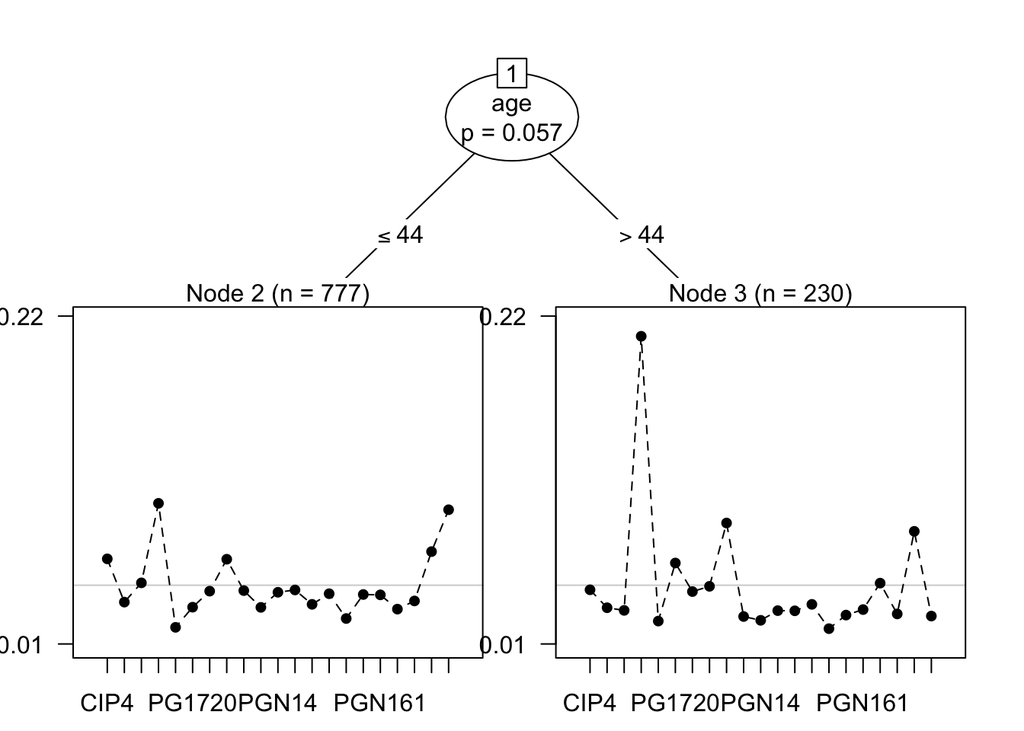

```r
plot(pl)
```

The function `plot_tree()` is still under development in the package gosset. With this function we can see the tree with the points and error bar.

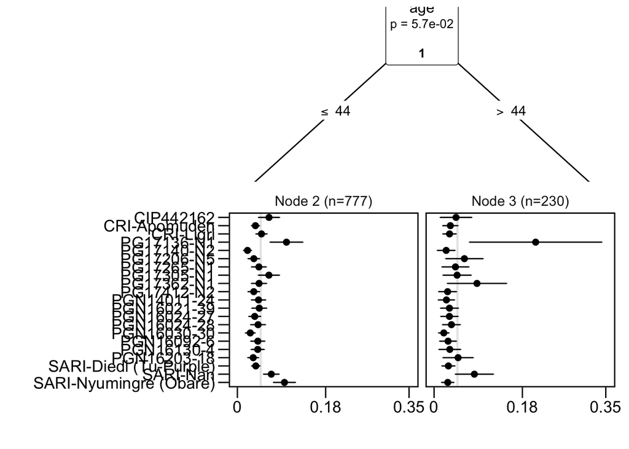

```r
gosset:::plot_tree(pl)
```

We can also extract the coefficients from each node like before.

```r
coef(pl)
```

```
##   CIP442162 CRI-Apomuden  CRI-Ligri PG17136-N1 PG17140-N2 PG17206-N5
## 2         0   -0.5613845 -0.2721977  0.4391743 -1.1393753 -0.6538218
## 3         0   -0.2973133 -0.3496924  1.5334272 -0.5949976  0.3248989
##    PG17265-N1   PG17305-N1 PG17362-N1 PG17412-N2 PGN14011-24 PGN16021-39
## 2 -0.38694033 -0.003811507 -0.3786803 -0.6572568  -0.4030712  -0.3693541
## 3 -0.02583033  0.048636011  0.6715318 -0.4829928  -0.5752502  -0.3548321
##   PGN16024-27 PGN16024-28 PGN16030-30 PGN16092-6 PGN16130-4 PGN16203-18
## 2  -0.6007577  -0.4250075  -0.8973138 -0.4369585 -0.4424469 -0.69148324
## 3  -0.3584040  -0.2340996  -0.8143235 -0.4501455 -0.3333179  0.09125216
##   SARI-Diedi (Tu-Purple)   SARI-Nan SARI-Nyumingre (Obare)
## 2             -0.5412468 0.06962682              0.3972741
## 3             -0.4244423 0.60873996             -0.4726361
```

The model can also be used for predictions with the function `predict()`

```r
head(predict(pl))
```

```
##      CIP442162 CRI-Apomuden  CRI-Ligri PG17136-N1 PG17140-N2 PG17206-N5
## 419 0.06450597   0.03679542 0.04913443  0.1000762 0.02064313 0.03354662
## 420 0.06450597   0.03679542 0.04913443  0.1000762 0.02064313 0.03354662
## 421 0.06450597   0.03679542 0.04913443  0.1000762 0.02064313 0.03354662
## 422 0.06450597   0.03679542 0.04913443  0.1000762 0.02064313 0.03354662
## 423 0.06450597   0.03679542 0.04913443  0.1000762 0.02064313 0.03354662
## 424 0.06450597   0.03679542 0.04913443  0.1000762 0.02064313 0.03354662
##     PG17265-N1 PG17305-N1 PG17362-N1 PG17412-N2 PGN14011-24 PGN16021-39
## 419 0.04380804 0.06426057  0.0441714 0.03343158  0.04310705  0.04458528
## 420 0.04380804 0.06426057  0.0441714 0.03343158  0.04310705  0.04458528
## 421 0.04380804 0.06426057  0.0441714 0.03343158  0.04310705  0.04458528
## 422 0.04380804 0.06426057  0.0441714 0.03343158  0.04310705  0.04458528
## 423 0.04380804 0.06426057  0.0441714 0.03343158  0.04310705  0.04458528
## 424 0.04380804 0.06426057  0.0441714 0.03343158  0.04310705  0.04458528
##     PGN16024-27 PGN16024-28 PGN16030-30 PGN16092-6 PGN16130-4 PGN16203-18
## 419  0.03537481  0.04217174  0.02629671 0.04167075 0.04144266   0.0323067
## 420  0.03537481  0.04217174  0.02629671 0.04167075 0.04144266   0.0323067
## 421  0.03537481  0.04217174  0.02629671 0.04167075 0.04144266   0.0323067
## 422  0.03537481  0.04217174  0.02629671 0.04167075 0.04144266   0.0323067
## 423  0.03537481  0.04217174  0.02629671 0.04167075 0.04144266   0.0323067
## 424  0.03537481  0.04217174  0.02629671 0.04167075 0.04144266   0.0323067
##     SARI-Diedi (Tu-Purple)   SARI-Nan SARI-Nyumingre (Obare)
## 419              0.0375439 0.06915737             0.09596964
## 420              0.0375439 0.06915737             0.09596964
## 421              0.0375439 0.06915737             0.09596964
## 422              0.0375439 0.06915737             0.09596964
## 423              0.0375439 0.06915737             0.09596964
## 424              0.0375439 0.06915737             0.09596964
```

# Example 2: Breadwheat data

The breadwheat is a dataframe from tricot trials of bread wheat (*Triticum aestivum* L.) varieties in India. This is a sample data available at [ClimMob](https://climmob.net/) that can be fetched using the function `getDataCM()` from ClimMobTools.

```r
key <- "d39a3c66-5822-4930-a9d4-50e7da041e77"

dt <- getDataCM(key = key,
                project = "breadwheat",
                pivot.wider = TRUE)


names(dt)
```

```
##  [1] "id"                                 "package_participant_name"
##  [3] "package_item_A"                     "package_item_B"
##  [5] "package_item_C"                     "package_project_name"
##  [7] "registration_surveyid"              "registration_survey_deviceimei"
##  [9] "registration_survey_start"          "registration_survey_end"
## [11] "registration_participant_name"      "registration_district"
## [13] "registration_village"               "registration_familiyofthefarmer"
## [15] "registration_age"                   "registration_gender"
## [17] "registration_telephone"             "registration_farm_geo_longitude"
## [19] "registration_farm_geo_latitude"     "lastassessment_surveyid"
## [21] "lastassessment_survey_deviceimei"   "lastassessment_survey_start"
## [23] "lastassessment_survey_end"          "lastassessment_grainquality_pos"
## [25] "lastassessment_grainquality_neg"    "lastassessment_yield_pos"
## [27] "lastassessment_yield_neg"           "lastassessment_overallperf_pos"
## [29] "lastassessment_overallperf_neg"     "firstassessment_surveyid"
## [31] "firstassessment_survey_deviceimei"  "firstassessment_survey_start"
## [33] "firstassessment_survey_end"         "firstassessment_earlygrowth_pos"
## [35] "firstassessment_earlygrowth_neg"    "firstassessment_plantingdate"
## [37] "firstassessment_farm_geo_longitude" "firstassessment_farm_geo_latitude"
```

We remove some strings in the colunm names

```r
names(dt) <- gsub("firstassessment_|package_|lastassessment_|registration_",
                  "",
                  names(dt))
```

## Tricot data with environmental covariates

We can add environmental covariates from package climatrends. Here we use the function `temperature()` to compute the temperature indices for the first 80 days after planting. We first convert the planting dates into an object of class `Date`, and the longitude and latitude into `numeric`.

```r
dt$plantingdate <- as.Date(dt$plantingdate, format = "%Y-%m-%d")
dt$lon <- as.numeric(dt$farm_geo_longitude)
dt$lat <- as.numeric(dt$farm_geo_latitude)

temp <- temperature(dt[, c("lon","lat")],
                    day.one = dt[, "plantingdate"],
                    span = 80)
```

```
## Getting climate data from NASA POWER
```

```r
temp
```

```
##      maxDT minDT maxNT minNT   DTR    SU    TR   CFD  WSDI  CSDI  T10p  T90p
##      <dbl> <dbl> <dbl> <dbl> <int> <int> <int> <int> <int> <int> <dbl> <dbl>
## 1:   30.75 20.65 17.67  4.63    15     2     0     0     3     2  5.50 27.73
## 2:   29.16 20.65 16.52  4.63    15     0     0     0     4     2  5.50 27.45
## 3:   32.77 20.65 18.49  4.63    15     7     0     0     8     2  5.50 29.17
## 4:   29.16 20.65 16.52  4.63    15     0     0     0     3     2  5.50 27.25
## 5:   29.16 20.65 16.52  4.63    15     0     0     0     4     2  5.50 26.22
## ---
## 489: 29.16 20.65 16.52  4.63    15     0     0     0     3     2  5.50 27.25
## 490: 29.16 20.65 16.52  4.63    15     0     0     0     3     2  5.50 27.25
## 491: 32.77 20.65 17.67  4.63    15     5     0     0     6     2  5.50 28.41
## 492: 29.16 20.65 16.52  4.63    15     0     0     0     3     2  5.50 27.25
## 493: 29.16 20.65 16.52  4.63    15     0     0     0     3     2  5.50 27.25
```

We build the farmers’ rankings as an object of class ‘grouped_rankings’.

```r
G <- rank_tricot(dt,
                 items = c("item_A","item_B","item_C"),
                 input = c("overallperf_pos","overallperf_neg"),
                 group = TRUE)

dat <- cbind(G, temp)
```

We fit the model using the function `pltree()`

```r
pl <- pltree(G ~ maxNT + maxDT,
             data = dat)

summary(pl)
```

```
## $`2`
## Call: PlackettLuce(rankings = y, weights = weights, na.action = NULL,
##     start = start)
##
## Coefficients:
##           Estimate Std. Error z value Pr(>|z|)
## CSW18       0.0000         NA      NA       NA
## DBW17      -1.4614     0.4132  -3.537 0.000405 ***
## DPW621-50  -2.0924     0.4376  -4.782 1.74e-06 ***
## HD2824     -3.1032     0.4347  -7.138 9.46e-13 ***
## HD2932     -2.7048     0.4320  -6.261 3.83e-10 ***
## HD2985     -2.0511     0.4413  -4.648 3.35e-06 ***
## HI1563     -3.4131     0.4425  -7.713 1.23e-14 ***
## HP1633     -3.4306     0.4323  -7.936 2.09e-15 ***
## HW2045     -3.5339     0.4396  -8.039 9.03e-16 ***
## K0307      -3.4931     0.4458  -7.835 4.67e-15 ***
## K9107       0.2791     0.4794   0.582 0.560486
## PBW343     -0.6595     0.4512  -1.462 0.143852
## PBW502     -3.1382     0.4539  -6.914 4.71e-12 ***
## PBW550     -3.2180     0.4269  -7.537 4.79e-14 ***
## RAJ4120    -3.0018     0.4331  -6.932 4.16e-12 ***
## WR544      -3.3246     0.4380  -7.590 3.20e-14 ***
## ---
## Signif. codes:  0 '***' 0.001 '**' 0.01 '*' 0.05 '.' 0.1 ' ' 1
##
## Residual deviance:  766.05 on 855 degrees of freedom
## AIC:  796.05
## Number of iterations: 25
##
## $`3`
## Call: PlackettLuce(rankings = y, weights = weights, na.action = NULL,
##     start = start)
##
## Coefficients:
##           Estimate Std. Error z value Pr(>|z|)
## CSW18       0.0000         NA      NA       NA
## DBW17      -0.7026     0.4481  -1.568 0.116904
## DPW621-50  -1.5821     0.4475  -3.535 0.000408 ***
## HD2824     -2.5380     0.4852  -5.231 1.69e-07 ***
## HD2932     -1.5077     0.4469  -3.374 0.000741 ***
## HD2985     -1.1698     0.4286  -2.729 0.006343 **
## HI1563     -2.3205     0.4502  -5.154 2.54e-07 ***
## HP1633     -2.1386     0.4676  -4.574 4.79e-06 ***
## HW2045     -1.9125     0.4482  -4.267 1.98e-05 ***
## K0307      -2.3455     0.4467  -5.251 1.51e-07 ***
## K9107       1.1110     0.5217   2.129 0.033215 *
## PBW343      0.2557     0.4366   0.586 0.558045
## PBW502     -1.9471     0.4245  -4.586 4.51e-06 ***
## PBW550     -2.1052     0.4693  -4.486 7.26e-06 ***
## RAJ4120    -2.5301     0.4974  -5.087 3.64e-07 ***
## WR544      -2.1327     0.4498  -4.741 2.13e-06 ***
## ---
## Signif. codes:  0 '***' 0.001 '**' 0.01 '*' 0.05 '.' 0.1 ' ' 1
##
## Residual deviance:  559.08 on 594 degrees of freedom
## AIC:  589.08
## Number of iterations: 16
```

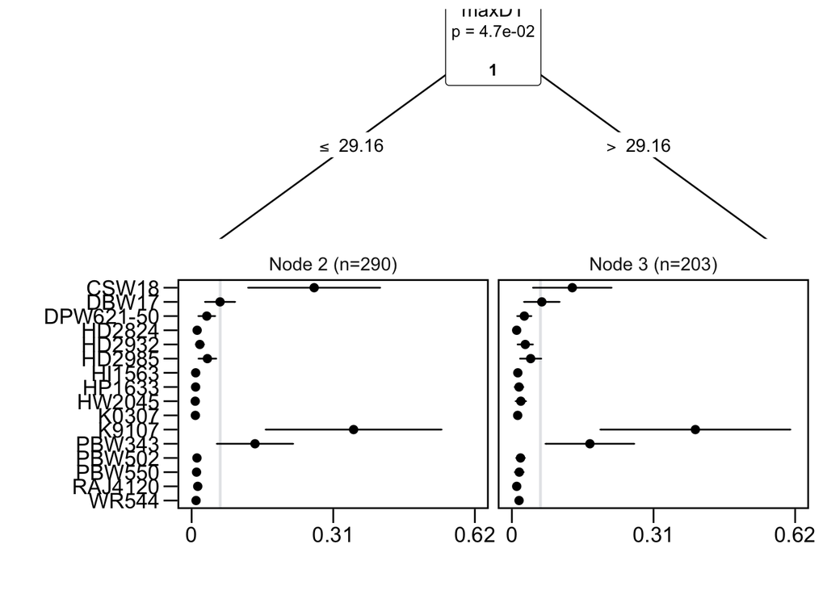

[figure not shown]

```r
gosset:::plot_tree(pl)
```

desousakaue k.desousa@cgiar.org